# Enteropathogen seroepidemiology among children in low-resource settings

Supplementary Information File 1. Effect of Kenya and Tanzania interventions on enteropathogen antibody response.

# Notebook summary

Morris JF, Murphy J, Fagerli K, Schneeberger C, Jaron P, Moke F, et al. A Randomized Controlled Trial to Assess the Impact of Ceramic Water Filters on Prevention of Diarrhea and Cryptosporidiosis in Infants and Young Children-Western Kenya, 2013. *Am J Trop Med Hyg.* 2018;98: 1260–1268. https://www.ncbi.nlm.nih.gov/pubmed/29611500

# Script preamble

```r
#-----------------------------
# preamble
#-----------------------------
library(here)
here()
```

```
## [1] "/Users/benarnold/enterics-seroepi"
```

```r
# load packages
library(tidyverse)
library(tmleAb) # development package: devtools::install_github("ben-arnold/tmleAb")
library(mgcv)
library(knitr)
library(kableExtra)
  options(knitr.table.format = "html")

# set up for parallel computing
# configure for a laptop (use only 3 cores)
library(foreach)
library(doParallel)
```

```r
registerDoParallel(cores=3)


# bright color blind palette:  https://personal.sron.nl/~pault/
cblack <- "#000004FF"
cblue <- "#3366AA"
cteal <- "#11AA99"
cgreen <- "#66AA55"
cchartr <- "#CCCC55"
cmagent <- "#992288"
cred <- "#EE3333"
corange <- "#EEA722"
cyellow <- "#FFEE33"
cgrey <- "#777777"
```

# Asembo, Kenya

## Load the data and format

```r
#-----------------------------
# load the formatted data
# with seropositivity indicators
# created with:
# asembo-enteric-ab-data-format.Rmd -->
# asembo-enteric-ab-distributions.Rmd
#-----------------------------
dl <- readRDS(here("data","asembo_analysis2.rds"))

# list the enteric antigens and make formatted labels for them
mbavars <- c("vsp3","vsp5","cp17","cp23","leca","salb","sald","p18","p39","etec","cholera")

mbalabs <- c("Giardia VSP-3","Giardia VSP-5","Cryptosporidium Cp17","Cryptosporidium Cp23","E. histolytica LecA","Salmonella LPS B","Salmonella LPS D","Campylobacter p18","Campylobacter p39","ETEC LT β subunit","Cholera toxin β subunit")
```

```r
#-----------------------------
# create composite
# seropositivity indicators
# that use information from
# multiple antigens
#-----------------------------

dgi <- dl %>%
  filter(antigen %in% c("vsp3","vsp5")) %>%
  select(childid,time,tr,sex,age,agediff,pathogen,antigen,seropos) %>%
  spread(antigen,seropos) %>%
  mutate(seropos=ifelse(vsp3==1|vsp5==1,1,0),
         antigen="vsp3vsp5",
         antigenf="Giardia VSP-3 or VSP-5") %>%
  select(-vsp3,-vsp5)

dcr <- dl %>%
  filter(antigen %in% c("cp17","cp23")) %>%
  select(childid,time,tr,sex,age,agediff,pathogen,antigen,seropos) %>%
  spread(antigen,seropos) %>%
  mutate(seropos=ifelse(cp17==1|cp23==1,1,0),
         antigen="cp17cp23",
         antigenf="Cryptosporidium Cp17 or Cp23") %>%
  select(-cp17,-cp23)

ds <- dl %>%
  filter(antigen %in% c("salb","sald")) %>%
  select(childid,time,tr,sex,age,agediff,pathogen,antigen,seropos) %>%
  spread(antigen,seropos) %>%
  mutate(seropos=ifelse(salb==1|sald==1,1,0),
         antigen="salbsald",
         antigenf="Salmonella LPS groups B or D") %>%
  select(-salb,-sald)

dcp <- dl %>%
  filter(antigen %in% c("p18","p39")) %>%
  select(childid,time,tr,sex,age,agediff,pathogen,antigen,seropos) %>%
  spread(antigen,seropos) %>%
  mutate(seropos=ifelse(p18==1|p39==1,1,0),
         antigen="p18p39",
         antigenf="Campylobacter p18 or p39") %>%
  select(-p18,-p39)



dlp <- bind_rows(dl,dgi,dcr,ds,dcp) %>%
  mutate(antigenf=factor(antigenf,
                         levels=c("Giardia VSP-3 or VSP-5",
                                  "Cryptosporidium Cp17 or Cp23",
                                  "E. histolytica LecA",
                                  "Salmonella LPS groups B or D",
                                  "ETEC LT β subunit",
                                  "Cholera toxin β subunit",
                                  "Campylobacter p18 or p39")) ) %>%
  filter(!is.na(antigenf)) %>%
  select(pathogen,antigen,antigenf,
         childid,time,tr,sex,age,agediff,
         mfi,logmfi,logmfidiff,
         roccut,mixcut,unexp,unexpcut,serocut,serocut_desc,
         posroc,posmix,posunex,seropos) %>%
  arrange(pathogen,antigenf,childid,time)

#-----------------------------
# create a dummy variable equal
# to 1 for all obs as a trick to
# get marginal predictions by
# age while still including REs
# for child
#-----------------------------
dlp <- dlp %>%
  mutate(dummy=1)
```

## Estimate curves in each treatment arm

```r
#----------------------------------
# simulataneous CIs for GAMs
# estimated by resampling the
# Baysian posterior estimates of
# the variance-covariance matrix
# assuming that it is multivariate normal
# the function below also estimates
# the unconditional variance-covariance
# matrix, Vb=vcov(x,unconditional=TRUE),
# which allows for undertainty in the actual
# estimated mean as well
# (Marra & Wood 2012 Scandinavian Journal of Statistics,
#  Vol. 39: 53–74, 2012, doi: 10.1111/j.1467-9469.2011.00760.x )
# simultaneous CIs provide much better coverage than pointwise CIs
# see: http://www.fromthebottomoftheheap.net/2016/12/15/simultaneous-interval-revisited/
#----------------------------------

gamCI <- function(m,newdata,nreps=10000) {
  require(mgcv)
  require(dplyr)
  Vb <- vcov(m,unconditional = TRUE)
  pred <- predict(m, newdata, se.fit = TRUE)
  fit <- pred$fit
  se.fit <- pred$se.fit
  BUdiff <- MASS::mvrnorm(n=nreps, mu = rep(0, nrow(Vb)), Sigma = Vb)
  Cg <- predict(m, newdata, type = "lpmatrix")
  simDev <- Cg %*% t(BUdiff)
  absDev <- abs(sweep(simDev, 1, se.fit, FUN = "/"))
  masd <- apply(absDev, 2L, max)
  crit <- quantile(masd, prob = 0.95, type = 8)
  pred <- data.frame(newdata,fit=pred$fit,se.fit=pred$se.fit)
  pred <- mutate(pred,
                 uprP = fit + (2 * se.fit),
                 lwrP = fit - (2 * se.fit),
                 uprS = fit + (crit * se.fit),
                 lwrS = fit - (crit * se.fit)
  )
  return(pred)
}


#-----------------------------
# fit cubic spline over age, separately for each
# treatment arm and antigen
# estimate approximate simultaneous confidence intervals
# for the fits
# set the dummy to 0 to
# zero out all of the random effects
# see posts on Stack Exchange for explanation:
# https://stats.stackexchange.com/questions/131106/predicting-with-random-effects-in-mgcv-gam/131116#131116
# https://stats.stackexchange.com/questions/189384/predicting-mean-smooth-in-gam-with-smooth-by-random-factor-interaction
#-----------------------------

library(mgcv)
pgamfits <- foreach(ab=levels(dlp$antigenf),.combine=rbind) %dopar% {
    pd <- filter(dlp, antigenf==ab)
    gfit <- mgcv::gam(seropos~s(age, bs="cr")+s(childid,bs="re",by=dummy)+tr, data=pd,family="binomial")
    newd0 <- pd %>% mutate(dummy=0,tr="Cont")
    newd1 <- pd %>% mutate(dummy=0,tr="Int")
    gsci0 <- gamCI(m=gfit,newdata=newd0,nreps=1000)
    gsci1 <- gamCI(m=gfit,newdata=newd1,nreps=1000)
    gsci <- bind_rows(gsci0,gsci1) %>% mutate(antigenf=ab)
    return(gsci)
}

# use antilogit to get back to prevalence from the logit link
pgamfits <- pgamfits %>%
  mutate(fit  = 1/(1+exp(-fit)),
         uprP = 1/(1+exp(-uprP)),
         lwrP = 1/(1+exp(-lwrP)),
         uprS = 1/(1+exp(-uprS)),
         lwrS = 1/(1+exp(-lwrS))) %>%
  mutate(antigenf=factor(antigenf,levels=levels(dlp$antigenf)),
         tr=factor(tr,levels=c("Cont","Int"),labels=c("Control","Intervention"))
  )
```

## Estimate seroprevalence by treatment arm

Estimate overall mean seroprevalence by treatment arm and compare arms. Standard errors account for repeated measurements within child using the influence curve.

```r
#-----------------------------
# estimate means by treatment
# arm and difference between
# arms using targeted maximum
# likelihood estimation
# get 95% CIs through the
# influence curve clustered
# on child ID
# adjust for age with GLM
#-----------------------------
tmlemeans <- foreach(tri=levels(dlp$tr),.combine=rbind) %:%
  foreach(ab=levels(dlp$antigenf),.combine=rbind) %dopar% {
    print(ab)
    pd <- filter(dlp,tr==tri & antigenf==ab)
    mu <- tmleAb(Y=pd$seropos,id=pd$childid,W=pd$age,
                 SL.library=c("SL.glm"),
                 family="binomial")
    di <- data.frame(tr=tri,antigenf=ab,mean=mu$psi,se=mu$se,lb=mu$lb,ub=mu$ub)
    return(di)
  }

tmlediffs <- foreach(ab=levels(dlp$antigenf),.combine=rbind) %dopar% {
    pd <- filter(dlp,antigenf==ab) %>% mutate(tr01=ifelse(tr=="Int",1,0))
    diffmu <- tmleAb(Y=pd$seropos,X=pd$tr01,W=pd$age,
                     id=pd$childid,SL.library=c("SL.glm"),
                     family="binomial")
    di <- data.frame(antigenf=ab,diff=diffmu$psi,lb=diffmu$lb,ub=diffmu$ub,p=diffmu$p)
    return(di)
  }

#-----------------------------
# report estimates in tables
#-----------------------------

# seroprevalence among intervention and control
tmlemeans %>%
  arrange(antigenf,tr) %>%
  knitr::kable(digits=2,caption="Seroprevalence by intervention group (Intervention, control)") %>%
  kable_styling(bootstrap_options = "striped",full_width = TRUE)
```

Seroprevalence by intervention group (Intervention, control)

| tr | antigenf | mean | se | lb | ub |
| --- | --- | --- | --- | --- | --- |
| Cont | Giardia VSP-3 or VSP-5 | 0.21 | 0.03 | 0.15 | 0.27 |
| Int | Giardia VSP-3 or VSP-5 | 0.22 | 0.03 | 0.17 | 0.27 |
| Cont | Cryptosporidium Cp17 or Cp23 | 0.38 | 0.03 | 0.31 | 0.45 |
| Int | Cryptosporidium Cp17 or Cp23 | 0.31 | 0.03 | 0.25 | 0.38 |
| Cont | E. histolytica LecA | 0.06 | 0.02 | 0.02 | 0.10 |
| Int | E. histolytica LecA | 0.05 | 0.02 | 0.02 | 0.09 |
| Cont | Salmonella LPS groups B or D | 0.08 | 0.02 | 0.05 | 0.12 |
| Int | Salmonella LPS groups B or D | 0.12 | 0.02 | 0.08 | 0.17 |
| Cont | ETEC LT β subunit | 0.88 | 0.02 | 0.83 | 0.93 |
| Int | ETEC LT β subunit | 0.88 | 0.02 | 0.84 | 0.93 |
| Cont | Cholera toxin β subunit | 0.84 | 0.03 | 0.78 | 0.89 |
| Int | Cholera toxin β subunit | 0.82 | 0.03 | 0.76 | 0.88 |
| Cont | Campylobacter p18 or p39 | 0.92 | 0.02 | 0.88 | 0.96 |
| Int | Campylobacter p18 or p39 | 0.90 | 0.02 | 0.85 | 0.95 |

```r
# difference between arms
knitr::kable(tmlediffs,digits=2,caption="Difference in seroprevalence (Intervention minus Control)")  %>%
  kable_styling(bootstrap_options = "striped",full_width = TRUE)
```

Difference in seroprevalence (Intervention minus Control)

| antigenf | diff | lb | ub | p |
| --- | --- | --- | --- | --- |
| Giardia VSP-3 or VSP-5 | 0.00 | -0.07 | 0.08 | 0.93 |
| Cryptosporidium Cp17 or Cp23 | -0.07 | -0.16 | 0.02 | 0.12 |
| E. histolytica LecA | -0.01 | -0.06 | 0.04 | 0.72 |
| Salmonella LPS groups B or D | 0.04 | -0.02 | 0.10 | 0.19 |
| ETEC LT β subunit | 0.01 | -0.05 | 0.07 | 0.74 |
| Cholera toxin β subunit | -0.01 | -0.09 | 0.06 | 0.73 |
| Campylobacter p18 or p39 | -0.02 | -0.07 | 0.04 | 0.58 |

No evidence for lower enteric antibody seroprevalence due to intervention.

## Figure of seroprevlance curves

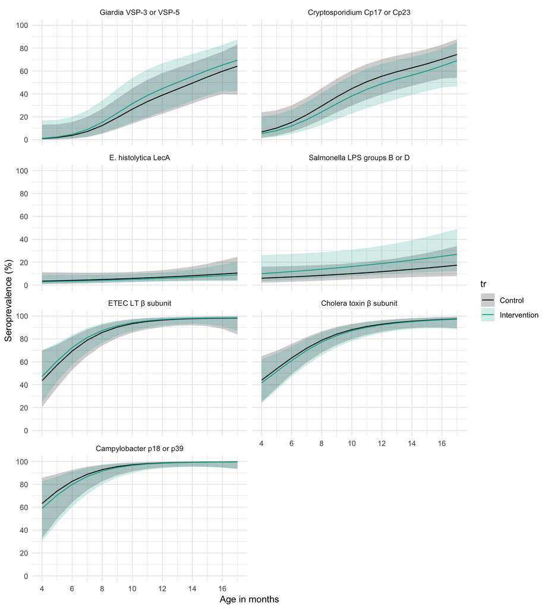

```r
# bright color-blind palette defined in an earlier code chunk
pcols <- c(cblack,cteal)

ppcurve <- ggplot(data=pgamfits,aes(x=age,color=tr,fill=tr)) +
  # approximate simultaneous CI from spline fit
  geom_ribbon(aes(ymin=lwrS,ymax=uprS),alpha=0.2,color=NA) +
  # spline fit
  geom_line(aes(y=fit)) +
  # plot aesthetics
  facet_wrap(~antigenf,nrow=7,ncol=2) +
  scale_x_continuous(limits=c(4,17),breaks=seq(4,16,by=2))+
  scale_y_continuous(breaks=seq(0,1,by=0.2),labels=sprintf("%1.0f",seq(0,1,by=0.2)*100))+
  coord_cartesian(ylim=c(0,1))+
  labs(x="Age in months",y="Seroprevalence (%)") +
  scale_fill_manual(values=pcols) +
  scale_color_manual(values=pcols) +
  theme_minimal() +
  theme(legend.position = "right")

ppcurve
```

# Kongwa, Tanzania

In Kongwa, Tanzania, antibody measurements were among children ages 1-9 years old. Without children <1, it was difficult to identify seropositivity cutoff values based on mixture models for any of the enteric pathogens (see main text). Therefore, there were only 3 pathogens (Giardia, Crypto, E. histolytica) where we could classify children as seropositive or seronegative becuase out-of-sample specimens were used to estimate cutoffs using an ROC curve.

In light of this limitation, below we compare the intervention and control groups using mean log MFI values, which is a reasonable alternative in this situation ([Arnold et al. 2017](http://journals.plos.org/plosntds/article?id=10.1371/journal.pntd.0005616).

*Salmonella* and *Campylobacter* antibodies were not measured after the first year enrollment survey in 2012. No clusters were treated at enrollment, therefore we cannot assess the effect of azithromycin treatment on these pathogens. Therefore, limit comparisons to years 2013-2015 to avoid any potential time trends, including those due to a change in bead lots from 2012 until the later years.

```r
#-----------------------------
# load the formatted data
# for enteric pathogens
# with seropositivity indicators
#-----------------------------
dl <- readRDS(here("data","kongwa_analysis2.rds"))

dl <- dl %>%
  filter(!antigen %in% c("salb","sald","p18","p39","pgp3")) %>%
  filter(!year %in% c(2012)) %>%
  mutate(antigenf=droplevels(antigenf),
         pathogen=droplevels(pathogen),
         tr=factor(ifelse(aztr==0,"Control","Intervention"),levels=c("Control","Intervention"))
  )
```

## Estimate curves in each treatment arm

```r
#-----------------------------
# fit cubic spline over age
# estimate approximate simultaneous confidence intervals
# for the fits
# include random effects for
# cluster to account for repeated
# observations
#-----------------------------
gamfits <- foreach(ab=levels(dl$antigenf),.combine=rbind) %dopar% {
    pd <- filter(dl, antigenf==ab) %>%
      mutate(dummy=1)
    gfit <- mgcv::gam(logmfi~s(age, bs="cr",k=9)+s(clusterid,bs="re",by=dummy)+tr ,data=pd,family="gaussian")
    newd0 <- pd %>% mutate(dummy=0,tr="Control")
    newd1 <- pd %>% mutate(dummy=0,tr="Intervention")
    gsci0 <- gamCI(m=gfit,newdata=newd0,nreps=1000)
    gsci1 <- gamCI(m=gfit,newdata=newd1,nreps=1000)
    gsci <- bind_rows(gsci0,gsci1) %>% mutate(antigenf=ab)
    return(gsci)
  }

gamfits <- gamfits %>%
  mutate(antigenf=factor(antigenf,levels=levels(dl$antigenf)),
         tr=factor(tr,levels=levels(dl$tr))
  )
```

## Estimate means by treatment arm

Estimate overall mean log MFI by treatment arm and compare arms. Standard errors account for repeated measurements within clusters using the influence curve.

```r
#-----------------------------
# estimate means by treatment
# arm and difference between
# arms using targeted maximum
# likelihood estimation
# get 95% CIs through the
# influence curve clustered
# on child ID
# adjust for age with glm
#-----------------------------
ktmlemeans <- foreach(tri=levels(dl$tr),.combine=rbind) %:%
  foreach(ab=levels(dl$antigenf),.combine=rbind) %dopar% {
    pd <- filter(dl,tr==tri & antigenf==ab)
    mu <- tmleAb(Y=pd$logmfi,id=pd$clusterid,W=select(pd,age),
                 SL.library=c("SL.glm"))
    di <- data.frame(tr=tri,antigenf=ab,mean=mu$psi,se=mu$se,lb=mu$lb,ub=mu$ub)
    return(di)
  }

ktmlediffs <- foreach(ab=levels(dl$antigenf),.combine=rbind) %dopar% {
    pd <- filter(dl,antigenf==ab) %>% mutate(tr01=ifelse(tr=="Control",0,1))
    diffmu <- tmleAb(Y=pd$logmfi,X=pd$tr01,W=select(pd,age),
                     id=pd$clusterid,SL.library=c("SL.glm"))
    di <- data.frame(antigenf=ab,diff=diffmu$psi,se=diffmu$se,lb=diffmu$lb,ub=diffmu$ub,p=diffmu$p)
    return(di)
  }

#-----------------------------
# report estimates in tables
#-----------------------------

# seroprevalence among intervention and control
knitr::kable(arrange(ktmlemeans,antigenf,tr),digits=2,caption="Mean MFI in the Intervention and Control groups")  %>%
  kable_styling(bootstrap_options = "striped",full_width = TRUE)
```

Mean MFI in the Intervention and Control groups

| tr | antigenf | mean | se | lb | ub |
| --- | --- | --- | --- | --- | --- |
| Control | Giardia VSP-3 | 2.55 | 0.04 | 2.48 | 2.62 |
| Intervention | Giardia VSP-3 | 2.62 | 0.02 | 2.58 | 2.67 |
| Control | Giardia VSP-5 | 2.64 | 0.04 | 2.56 | 2.71 |
| Intervention | Giardia VSP-5 | 2.71 | 0.02 | 2.66 | 2.75 |
| Control | Cryptosporidium Cp17 | 3.20 | 0.04 | 3.12 | 3.27 |
| Intervention | Cryptosporidium Cp17 | 3.22 | 0.02 | 3.17 | 3.27 |
| Control | Cryptosporidium Cp23 | 3.36 | 0.03 | 3.29 | 3.42 |
| Intervention | Cryptosporidium Cp23 | 3.40 | 0.02 | 3.35 | 3.44 |
| Control | E. histolytica LecA | 2.08 | 0.06 | 1.95 | 2.20 |
| Intervention | E. histolytica LecA | 2.32 | 0.04 | 2.24 | 2.40 |
| Control | ETEC LT β subunit | 4.30 | 0.02 | 4.27 | 4.33 |
| Intervention | ETEC LT β subunit | 4.33 | 0.01 | 4.31 | 4.35 |
| Control | Cholera toxin β subunit | 3.99 | 0.03 | 3.94 | 4.04 |
| Intervention | Cholera toxin β subunit | 4.01 | 0.02 | 3.98 | 4.05 |

```r
# difference between groups
knitr::kable(ktmlediffs,digits=2,caption="Difference in MFI (Intervention minus Control)")  %>%
  kable_styling(bootstrap_options = "striped",full_width = TRUE)
```

Difference in MFI (Intervention minus Control)

| antigenf | diff | se | lb | ub | p |
| --- | --- | --- | --- | --- | --- |
| Giardia VSP-3 | 0.07 | 0.04 | -0.02 | 0.15 | 0.14 |
| Giardia VSP-5 | 0.06 | 0.05 | -0.03 | 0.15 | 0.19 |
| Cryptosporidium Cp17 | 0.02 | 0.04 | -0.07 | 0.11 | 0.63 |
| Cryptosporidium Cp23 | 0.04 | 0.04 | -0.04 | 0.12 | 0.32 |
| E. histolytica LecA | 0.25 | 0.08 | 0.09 | 0.41 | 0.00 |
| ETEC LT β subunit | 0.02 | 0.02 | -0.01 | 0.06 | 0.23 |
| Cholera toxin β subunit | 0.02 | 0.03 | -0.04 | 0.09 | 0.51 |

Below, estimate the difference between arms in LecA seroprevalence, which suggests a higher seroprevalence in the intervention clusters that received annual azythromycin distribution (21% relative increase).

```r
leca_serop <- foreach(tri=levels(dl$tr),.combine=rbind) %dopar% {
    pd <- filter(dl,tr==tri & antigenf=="E. histolytica LecA")
    mu <- tmleAb(Y=pd$posroc,id=pd$clusterid,W=select(pd,age),
                 SL.library=c("SL.glm"),family="binomial")
    di <- data.frame(tr=tri,antigenf="E. histolytica LecA", mean=mu$psi,se=mu$se,lb=mu$lb,ub=mu$ub)
    return(di)
}


pd <- dl %>%
  filter(antigenf=="E. histolytica LecA") %>%
  mutate(tr01=ifelse(tr=="Control",0,1))
leca_diff <- tmleAb(Y=pd$posroc,X=pd$tr01,W=select(pd,age),
                     id=pd$clusterid,SL.library=c("SL.glm"),
                    family="binomial")
```

```
##  Additive Effect
##    Parameter Estimate:  0.10546
##    Estimated Variance:  0.0017945
##               p-value:  0.012793
##     95% Conf Interval: (0.02243, 0.18849)
##
##  Additive Effect among the Treated
##    Parameter Estimate:  0.1055
##    Estimated Variance:  0.0017947
##               p-value:  0.012766
##     95% Conf Interval: (0.022463, 0.18853)
##
##  Additive Effect among the Controls
##    Parameter Estimate:  0.10568
##    Estimated Variance:  0.0017941
##               p-value:  0.012599
##     95% Conf Interval: (0.022657, 0.18869)
##
##  Relative Risk
##    Parameter Estimate:  1.2091
##               p-value:  0.020537
##     95% Conf Interval: (1.0296, 1.4199)
##
##               log(RR):  0.18988
##     variance(log(RR)):  0.0067198
##
##  Odds Ratio
##    Parameter Estimate:  1.5359
##               p-value:  0.011999
##     95% Conf Interval: (1.0989, 2.1466)
##
##               log(OR):  0.42911
##     variance(log(OR)):  0.029176
```

## Figure of mean curves

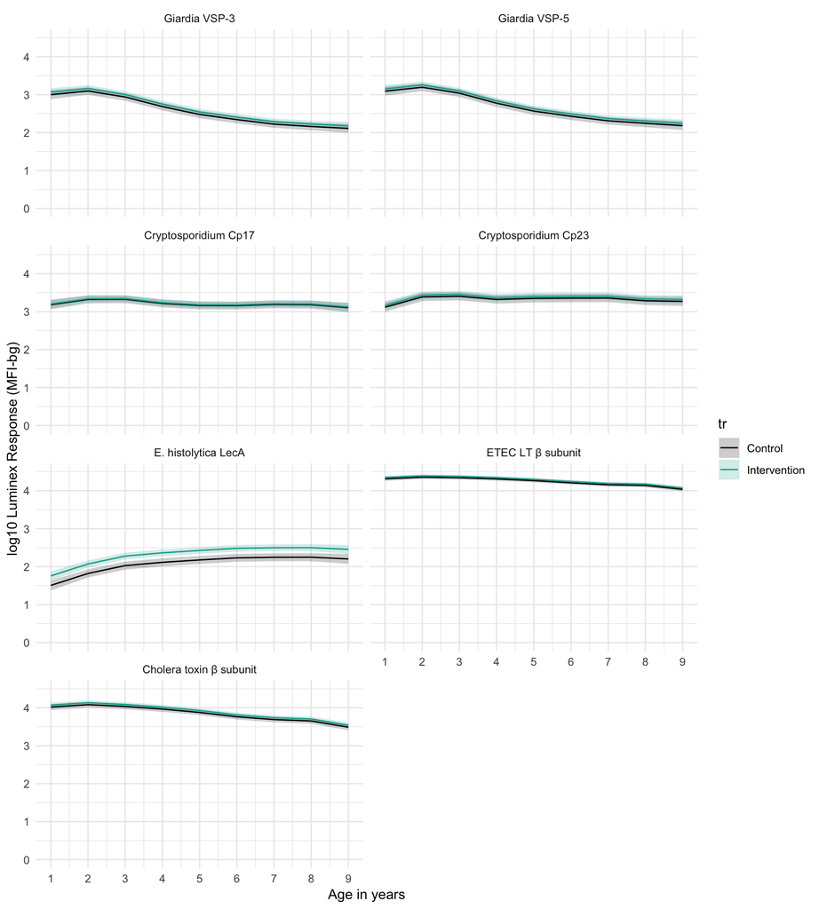

```r
# bright color-blind palette defined in an earlier code chunk
pcols <- c(cblack,cteal)

mucurve <- ggplot(data=gamfits,aes(x=age,color=tr,fill=tr)) +
  # approximate simultaneous CI from spline fit
  geom_ribbon(aes(ymin=lwrS,ymax=uprS),alpha=0.2,color=NA) +
  # spline fit
  geom_line(aes(y=fit)) +
  # plot aesthetics
  facet_wrap(~antigenf,nrow=7,ncol=2) +
  scale_x_continuous(limits=c(1,9),breaks=1:9)+
  scale_y_continuous(breaks=seq(0,4,by=1))+
  coord_cartesian(ylim=c(0,4.5))+
  labs(x="Age in years",y="log10 Luminex Response (MFI-bg)") +
  scale_fill_manual(values=pcols) +
  scale_color_manual(values=pcols) +
  theme_minimal() +
  theme(legend.position = "right")

mucurve
```